# Final Code Section

Yueze Xu

2021-04-21

# Instructions

You will need to complete the portion of the exam before starting the second portion. You will use your answers on this exam to complete the second half. Only knitted files will be graded! Make sure your complete this portion of the exam on your own. Use your notes and class examples to get started with the code.

# Abstract

Much attention has been devoted to how technological advancements have created a brave new workplace, revolutionizing the ways in which work is being carried out, and how employees can improve their productivity and efficiency. However, the advent of technology has also opened up new avenues and opportunities for individuals to misbehave. This study focused on cyberloafing—the act of employees using their companies’ internet access for personal purposes during work hours. Cyberloafing, thus, represents a form of production deviance. Using the theoretical frameworks offered by social exchange, organizational justice and neutralization, we examined the often-neglected dark side of the internet and the role that neutralization techniques play in facilitating this misbehavior at the workplace. Specifically, we developed a model, which suggested that when individuals perceived their organizations to be distributively, procedurally and interactionally unjust, they were likely to invoke the metaphor of the ledger as a neutralization technique to legitimize their subsequent engagement in the act of cyberloafing.

*Citation:* Lim, V. K. (2002). The IT way of loafing on the job: cyberloafing, neutralizing and organizational justice. Journal of Organizational Behavior, 23, 675-694. doi: 10.1002/job.161

# Method

Participants were given interviews to determine their perception of the company. After their interview the amount of cyberloafing (minutes per day) was measured using different types of computer stations. All employees were measured at each type of station.

# Dataset:

- Gender of the worker: male or female
- Perception of company: unjust, neutral, fair
- Cyberloafing: a measure of the amount of cyberloafing for several months
- Workstation distance: distance of workstation from boss
- Length of time: time spent working at current job

In this section, the data will be loaded for you from the package. You will change the id = 123456 to your HU id number. This number will generate your data for you in the same time each way, so if you rerun this analysis, you will get the same numbers each time.

```r
library(learnSTATS)
final <- final_data(idnum = 285987)
head(final)
```

```
##   gender perception cyberloafing  distance    length
## 1 female       fair    14.944871 18.720777  0.840117
## 2 female       fair    11.057928  5.750960 18.460776
## 3 female       fair    16.723660 10.014596 13.368526
## 4 female       fair     9.254781  5.602010 15.115202
## 5 female       fair     7.733604  6.322755 20.839990
## 6 female       fair    13.595102 13.337632  9.001309
```

# One-way ANOVA

- Are there differences in cyberloafing based on the perception of the company? Use a one-way ANOVA to determine if there are group differences.
- Run the ANOVA using the `ez` library.  
  **I did assumption test first, Levene’s test shows significant, p-value is smaller than .05**  
  **The One-Way ANOVA test result shows p-value is smaller than .05, which reject the null hypothesis, which there is a significant difference between cyberloafing and perception.**

```r
library(ez, quietly = T)
#I did factor function on the variable 'gender' and 'perception'
str(final)
```

```
## 'data.frame':    306 obs. of  5 variables:
##  $ gender      : chr  "female" "female" "female" "female" ...
##  $ perception  : chr  "fair" "fair" "fair" "fair" ...
##  $ cyberloafing: num  14.94 11.06 16.72 9.25 7.73 ...
##  $ distance    : num  18.72 5.75 10.01 5.6 6.32 ...
##  $ length      : num  0.84 18.46 13.37 15.12 20.84 ...
```

```r
f <- c('gender','perception')
final[f] <-lapply(final[f], factor)
summary(final)
```

```
##     gender      perception   cyberloafing         distance
##  female:153   fair   :102   Min.   : 0.01517   Min.   : 0.0613
##  male  :153   neutral:102   1st Qu.:13.01914   1st Qu.: 6.7400
##               unjust :102   Median :20.71789   Median : 9.3250
##                             Mean   :23.31393   Mean   : 9.2482
##                             3rd Qu.:32.40834   3rd Qu.:11.2218
##                             Max.   :62.11275   Max.   :18.7208
##      length
##  Min.   : 0.8401
##  1st Qu.:13.9202
##  Median :19.8491
##  Mean   :19.7567
##  3rd Qu.:25.1475
##  Max.   :41.6983
```

```r
#Run the assumption test
#create participant number for ezANOVA
final$partno <- 1:nrow(final)
ezANOVA(data = final,
        dv = cyberloafing,
        between = perception,
        wid = partno,
        type = 3,
        detailed = T)
```

```
## Coefficient covariances computed by hccm()
```

```
## $ANOVA
##        Effect DFn DFd       SSn      SSd         F             p p<.05
## 1 (Intercept)   1 303 166323.04 11109.32 4536.3603 2.333394e-184     *
## 2  perception   2 303  39675.87 11109.32  541.0677 1.005739e-100     *
##         ges
## 1 0.9373884
## 2 0.7812488
##
## $`Levene's Test for Homogeneity of Variance`
##   DFn DFd      SSn      SSd        F           p p<.05
## 1   2 303 1695.686 4539.008 56.59748 1.30344e-21     *
```

```r
##running the one-way ANOVA
oneway.test(cyberloafing ~ perception, data = final)
```

```
##
##  One-way analysis of means (not assuming equal variances)
##
## data:  cyberloafing and perception
## F = 507.01, num df = 2.00, denom df = 176.36, p-value < 2.2e-16
```

# Post Hoc

- Run a post hoc test and correction on company perception.  
  **First, I run the the post hoc without correction and then compare the result with Bonferroni correction test. The correction result shows no ajust P value and the P value is significant.**

```r
##post hoc tests - p.value adjustment "none"
pairwise.t.test(final$cyberloafing,
                final$perception,
                p.adjust.method = "none",
                paired = F,
                var.equal = T)
```

```
##
##  Pairwise comparisons using t tests with pooled SD
##
## data:  final$cyberloafing and final$perception
##
##         fair   neutral
## neutral <2e-16 -
## unjust  <2e-16 <2e-16
##
## P value adjustment method: none
```

```r
## post hoc tests - p.value adjustment "bonferroni"
pairwise.t.test(final$cyberloafing,
                final$perception,
                p.adjust.method = "bonferroni",
                paired = F,
                var.equal = T)
```

```
##
##  Pairwise comparisons using t tests with pooled SD
##
## data:  final$cyberloafing and final$perception
##
##         fair   neutral
## neutral <2e-16 -
## unjust  <2e-16 <2e-16
##
## P value adjustment method: bonferroni
```

# Correlations

- Include a correlation table of all the continuous variables with the `Hmisc` library.  
  **From the correlation table, the length of time has the strongest correlation with cyverloafing**

```r
library(Hmisc, quietly = T)
##Only select the continuous variable from the raw data set.
rcorr(as.matrix(na.omit(final[,3:5])), type = 'pearson')
```

```
##              cyberloafing distance length
## cyberloafing         1.00     0.63   0.75
## distance             0.63     1.00   0.02
## length               0.75     0.02   1.00
##
## n= 306
##
##
## P
##              cyberloafing distance length
## cyberloafing              0.0000   0.0000
## distance     0.0000                0.7214
## length       0.0000       0.7214
```

```r
library(cocor, quietly = T)
cocor(~cyberloafing + distance|cyberloafing + length, data= final)
```

```
##
##   Results of a comparison of two overlapping correlations based on dependent groups
##
## Comparison between r.jk (cyberloafing, distance) = 0.632 and r.jh (cyberloafing, length) = 0.7494
## Difference: r.jk - r.jh = -0.1174
## Related correlation: r.kh = 0.0205
## Data: final: j = cyberloafing, k = distance, h = length
## Group size: n = 306
## Null hypothesis: r.jk is equal to r.jh
## Alternative hypothesis: r.jk is not equal to r.jh (two-sided)
## Alpha: 0.05
##
## pearson1898: Pearson and Filon's z (1898)
##   z = -2.7208, p-value = 0.0065
##   Null hypothesis rejected
##
## hotelling1940: Hotelling's t (1940)
##   t = -6.0608, df = 303, p-value = 0.0000
##   Null hypothesis rejected
##
## williams1959: Williams' t (1959)
##   t = -2.7550, df = 303, p-value = 0.0062
##   Null hypothesis rejected
##
## olkin1967: Olkin's z (1967)
##   z = -2.7208, p-value = 0.0065
##   Null hypothesis rejected
##
## dunn1969: Dunn and Clark's z (1969)
##   z = -2.7485, p-value = 0.0060
##   Null hypothesis rejected
##
## hendrickson1970: Hendrickson, Stanley, and Hills' (1970) modification of Williams' t (1959)
##   t = -6.0605, df = 303, p-value = 0.0000
##   Null hypothesis rejected
##
## steiger1980: Steiger's (1980) modification of Dunn and Clark's z (1969) using average correlations
##   z = -2.7425, p-value = 0.0061
##   Null hypothesis rejected
##
## meng1992: Meng, Rosenthal, and Rubin's z (1992)
##   z = -2.7489, p-value = 0.0060
##   Null hypothesis rejected
##   95% confidence interval for r.jk - r.jh: -0.3885 -0.0651
##   Null hypothesis rejected (Interval does not include 0)
##
## hittner2003: Hittner, May, and Silver's (2003) modification of Dunn and Clark's z (1969) using a backtransformed average Fisher's (1921) Z procedure
##   z = -2.7547, p-value = 0.0059
##   Null hypothesis rejected
##
## zou2007: Zou's (2007) confidence interval
##   95% confidence interval for r.jk - r.jh: -0.2041 -0.0334
##   Null hypothesis rejected (Interval does not include 0)
```

# Hierarchical Regression:

- Use a hierarchical regression predicting cyberloafing with the following steps:
  - Step 1: Gender
  - Step 2: Perception of Company
  - Step 3: Length of time, workstation distance
- Include the `summary()` at each step. Include an `anova()` on all three models to be able to examine the changes in each step.  
  **For step 1, it is not significant. And Step 2 and Step 3 shows significantly changes of R-squared. Also, step 2 added the most variance. Also, in step 1, gender male is not significant, perceptionneutral is not significant in step 3.**

```r
step1 <- lm(cyberloafing ~ gender, data = final)
step2 <- lm(cyberloafing ~ gender + perception, data = final)
step3 <- lm(cyberloafing ~ gender + perception + length + distance, data = final)

summary(step1)
```

```
##
## Call:
## lm(formula = cyberloafing ~ gender, data = final)
##
## Residuals:
##     Min      1Q  Median      3Q     Max
## -22.493 -10.720  -2.682   8.978  37.993
##
## Coefficients:
##             Estimate Std. Error t value Pr(>|t|)
## (Intercept)   24.120      1.043  23.128   <2e-16 ***
## gendermale    -1.612      1.475  -1.093    0.275
## ---
## Signif. codes:  0 '***' 0.001 '**' 0.01 '*' 0.05 '.' 0.1 ' ' 1
##
## Residual standard error: 12.9 on 304 degrees of freedom
## Multiple R-squared:  0.003913,   Adjusted R-squared:  0.0006364
## F-statistic: 1.194 on 1 and 304 DF,  p-value: 0.2753
```

```r
summary(step2)
```

```
##
## Call:
## lm(formula = cyberloafing ~ gender + perception, data = final)
##
## Residuals:
##     Min      1Q  Median      3Q     Max
## -35.027  -2.668   0.065   2.538  23.038
##
## Coefficients:
##                   Estimate Std. Error t value Pr(>|t|)
## (Intercept)        11.4707     0.6872  16.692   <2e-16 ***
## gendermale         -1.6117     0.6872  -2.345   0.0197 *
## perceptionneutral  10.3429     0.8417  12.289   <2e-16 ***
## perceptionunjust   27.6044     0.8417  32.798   <2e-16 ***
## ---
## Signif. codes:  0 '***' 0.001 '**' 0.01 '*' 0.05 '.' 0.1 ' ' 1
##
## Residual standard error: 6.011 on 302 degrees of freedom
## Multiple R-squared:  0.7852, Adjusted R-squared:  0.783
## F-statistic: 367.9 on 3 and 302 DF,  p-value: < 2.2e-16
```

```r
summary(step3)
```

```
##
## Call:
## lm(formula = cyberloafing ~ gender + perception + length + distance,
##     data = final)
##
## Residuals:
##     Min      1Q  Median      3Q     Max
## -8.6184 -1.6786 -0.0097  1.5290  8.6719
##
## Coefficients:
##                    Estimate Std. Error t value Pr(>|t|)
## (Intercept)       -20.91117    1.03333 -20.237  < 2e-16 ***
## gendermale          1.72372    0.33654   5.122 5.42e-07 ***
## perceptionneutral  -0.30087    0.51284  -0.587 0.557859
## perceptionunjust    2.97071    0.85479   3.475 0.000585 ***
## length              1.12170    0.03882  28.895  < 2e-16 ***
## distance            2.19633    0.07194  30.529  < 2e-16 ***
## ---
## Signif. codes:  0 '***' 0.001 '**' 0.01 '*' 0.05 '.' 0.1 ' ' 1
##
## Residual standard error: 2.802 on 300 degrees of freedom
## Multiple R-squared:  0.9536, Adjusted R-squared:  0.9529
## F-statistic:  1234 on 5 and 300 DF,  p-value: < 2.2e-16
```

```r
anova(step1, step2, step3)
```

```
## Analysis of Variance Table
##
## Model 1: cyberloafing ~ gender
## Model 2: cyberloafing ~ gender + perception
## Model 3: cyberloafing ~ gender + perception + length + distance
##   Res.Df   RSS Df Sum of Sq       F    Pr(>F)
## 1    304 50586
## 2    302 10911  2     39676 2527.52 < 2.2e-16 ***
## 3    300  2355  2      8556  545.05 < 2.2e-16 ***
## ---
## Signif. codes:  0 '***' 0.001 '**' 0.01 '*' 0.05 '.' 0.1 ' ' 1
```

# Mediation or Moderation

```r
library(MeMoBootR, quietly = T)
#Mediation
output <- mediation1(y ='cyberloafing', x='distance', m='length', df = final)
```

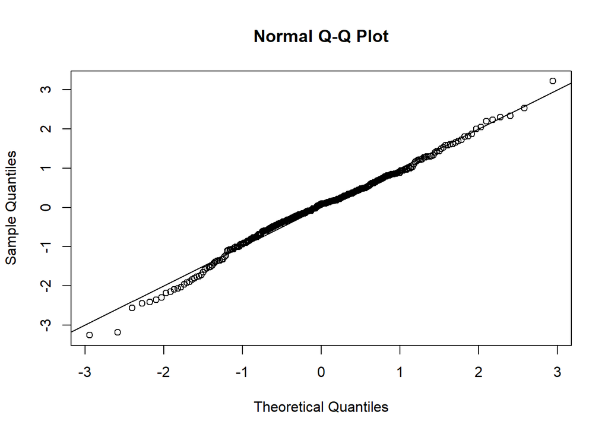

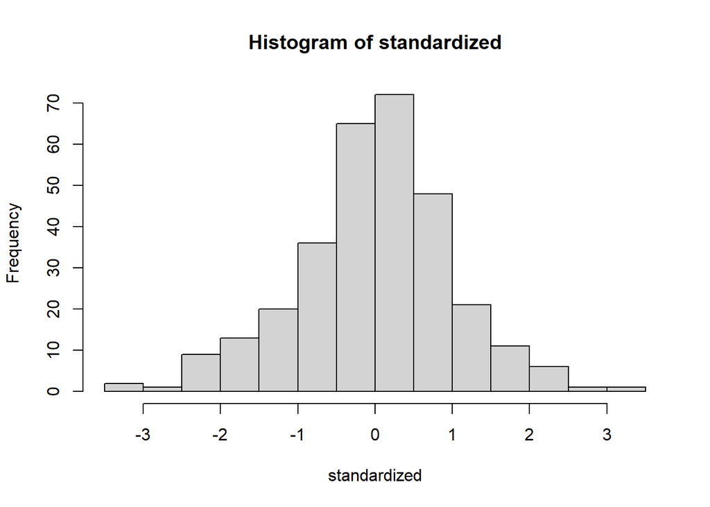

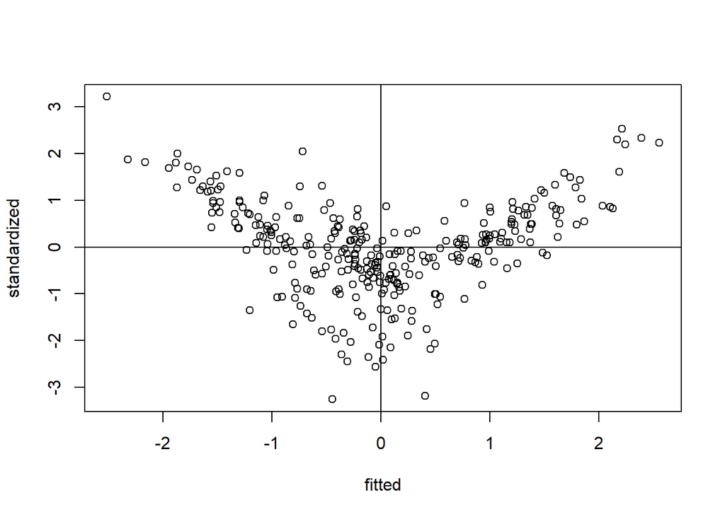

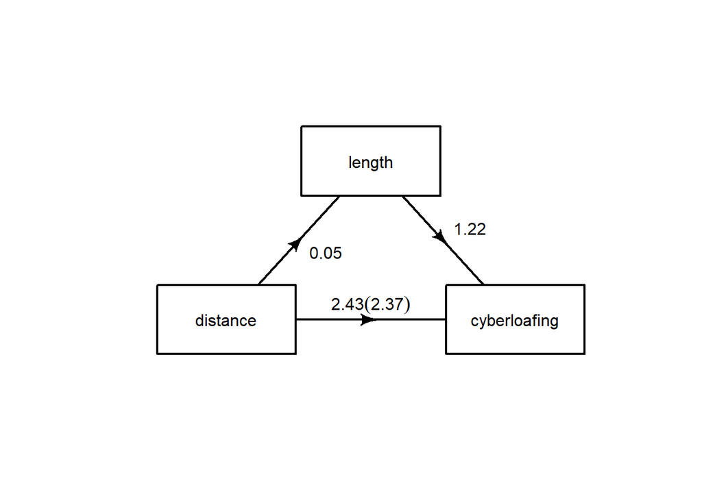

```r
output$z.score;output$p.value
```

```
##  distance
## 0.3568724
```

```
##  distance
## 0.7211873
```

```r
output$boot.ci
```

```
## BOOTSTRAP CONFIDENCE INTERVAL CALCULATIONS
## Based on 1000 bootstrap replicates
##
## CALL :
## boot.ci(boot.out = bootresults, conf = conf_level, type = "norm")
##
## Intervals :
## Level      Normal
## 95%   (-0.2802,  0.4034 )
## Calculations and Intervals on Original Scale
```

```r
#Moderation
output1 <- moderation1(y ='cyberloafing', x='distance', m='length', df = final)
```

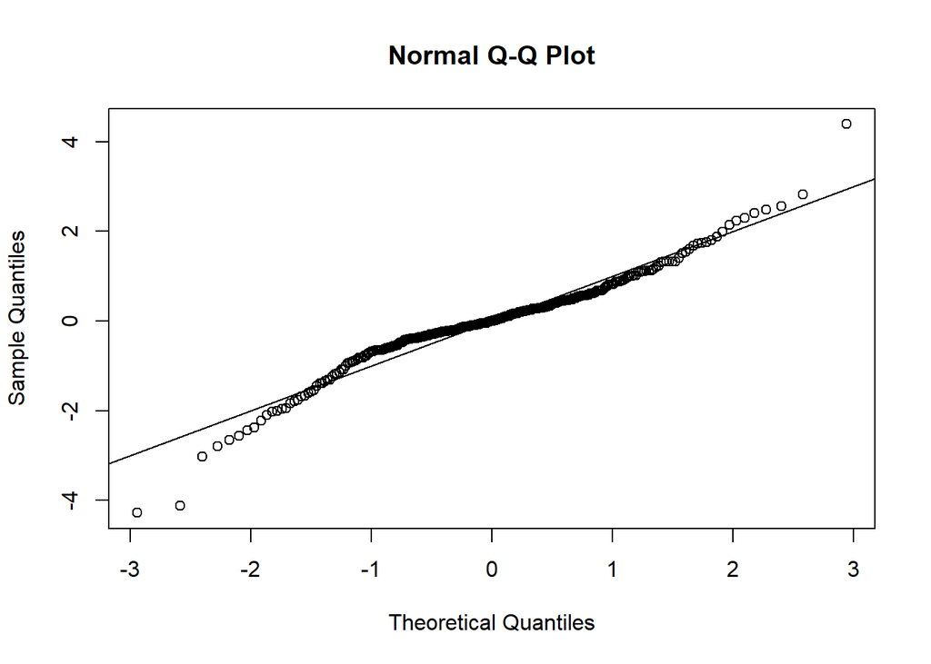

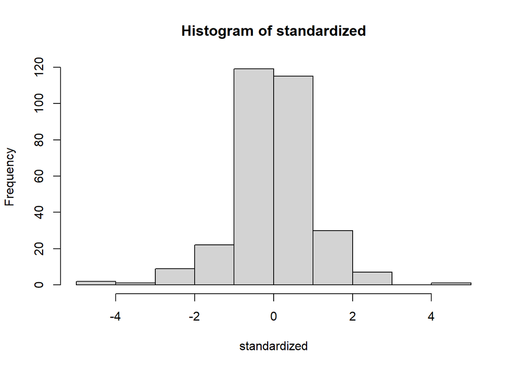

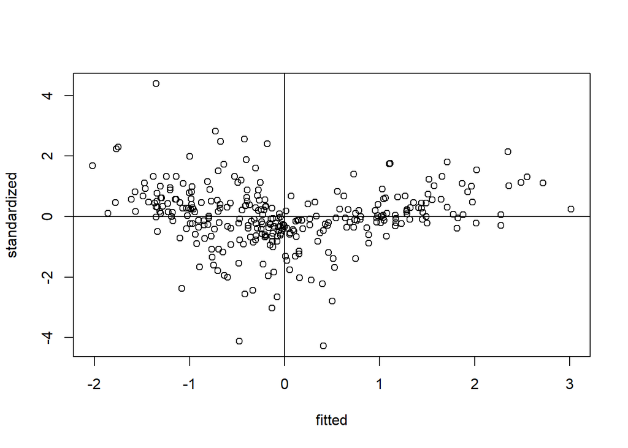

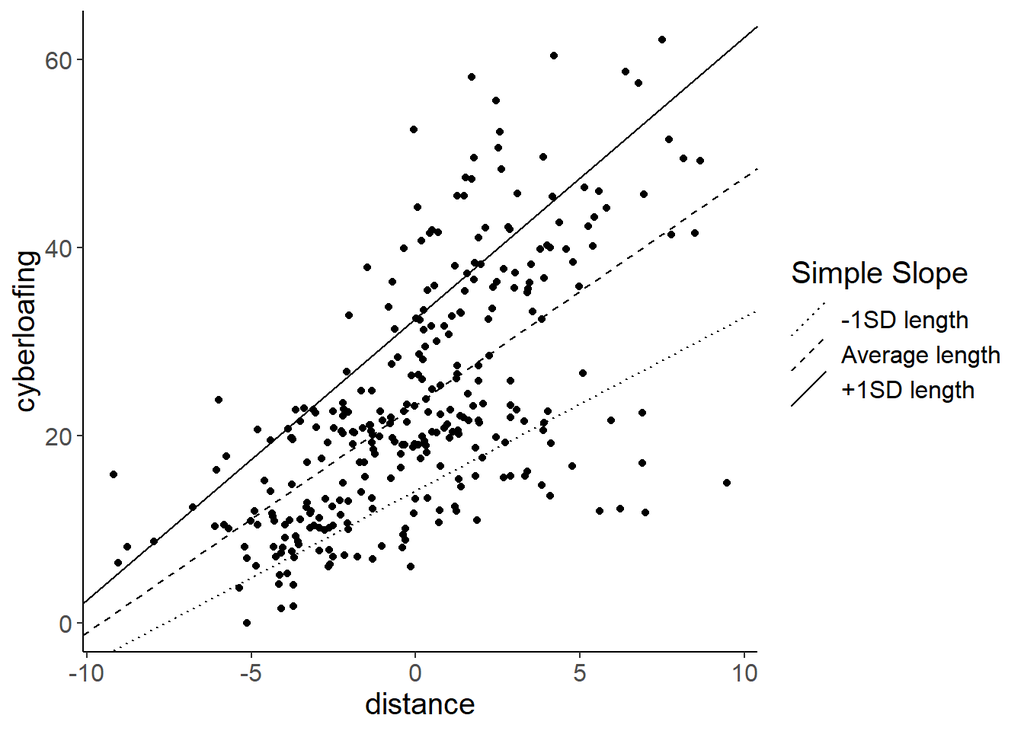

```r
output1$graphslopes
```

```r
summary(output1$model1)
```

```
##
## Call:
## lm(formula = allformulas$eq1, data = finaldata)
##
## Residuals:
##     Min      1Q  Median      3Q     Max
## -9.8662 -0.9478 -0.0029  1.1875  9.7011
##
## Coefficients:
##                 Estimate Std. Error t value Pr(>|t|)
## (Intercept)     23.27475    0.13589  171.28   <2e-16 ***
## distance         2.42154    0.04071   59.48   <2e-16 ***
## length           1.18162    0.01773   66.64   <2e-16 ***
## distance:length  0.07366    0.00497   14.82   <2e-16 ***
## ---
## Signif. codes:  0 '***' 0.001 '**' 0.01 '*' 0.05 '.' 0.1 ' ' 1
##
## Residual standard error: 2.377 on 302 degrees of freedom
## Multiple R-squared:  0.9664, Adjusted R-squared:  0.9661
## F-statistic:  2896 on 3 and 302 DF,  p-value: < 2.2e-16
```